# Churn

Eva Manuela Roncancio Ruiz, Mayerlis Lissett Moya Villafane, Guillermo Luigui Ubaldo Nieto Angarita.

2024-11-07

# **PREDICCIÓN DE LA PÉRDIDA DE CLIENTES DE TELECOMUNICACIONES**

*Eva Manuela Roncancio Ruiz, Mayerlis Lissett Moya Villafane , Guillermo Luigui Ubaldo Nieto Angarita.*

## **1. Contexto.**

Este conjunto de datos consta de 100 variables y aproximadamente 100.000 registros. Se presentan distintas variables que explican los atributos propios del sector de las telecomunicaciones y diversos factores esenciales para atender las necesidades de sus clientes.

La variable objetivo es la **rotación** (churn), que explica si el cliente cambiará de proveedor o no.

El sector de las telecomunicaciones es un mercado muy competitivo en el cual las compañías de telefonía celular generan atractivas campañas de publicidad que den valor agregado al cliente para lograr su estadía a largo plazo. Asimismo, este servicio demanda un considerable cuidado con los factores intangibles que pueden ocasionar que un usuario busque realizar portabilidades numéricas o cancelaciones definitivas. Por tal motivo, las variables que se consideran en el modelo deben reflejar los aspectos más importantes que puedan ser un factor de decisión para el cliente.

Por otra parte, la segmentación del mercado es importante para la retención y rotación. Si bien el precio es primordial y puede generar una rápida y masiva vinculación de usuarios, la calidad dada por las compañías durante la prestación del servicio es indispensable para evitar portabilidades numéricas prematuras. Por esta razón, se debe entender que algunas variables serán de mayor importancia para unos clientes que para otros.

Así bien, con este modelo se pretende analizar y entender los factores decisivos para el cliente, a fin de predecir su comportamiento comercial y permitir a los lideres del negocio tomar decisiones enfocadas en las variables que le dan este valor agregado a su servicio y que impactan en la permanencia de su mercado objetivo.

## **2. Objetivos.**

### *2.1 Objetivo General*

Crear un modelo de Machine Learning para predecir los clientes que abandonarán los servicios de telecomunicaciones en función de las variables objeto de estudio seleccionadas en este proyecto.

### *2.2 Objetivos Especificos*

1. Presentar un EDA Univariado y Multivariado a profundidad.
2. Hacer uso de pruebas de Algoritmos para la comparación del rendimiento.
3. Optimizar el modelo con pruebas de Algoritmo mediante tecnicas de hiperparametro.
4. Presentar el modelo más optimo para la predicción del churn en el sector de las telecomunicaciones junto con el analisis de aplicabilidad.

## **3. Variables Objeto.**

### *3.1 Variable Dependiente*

Churn: Reporte de los casos de abandono (con evolución entre 31 a 60 días después de la fecha de observación)

### *3.2 Variables Independientes*

Seleccioandas en la Limpieza y Transformación de los Datos

## **4. Cargue de los Datos (paquetes, librerías, data)**

A continuación, se presenta el código desarrollado para la recolección, cargue, preparación y exploración de los datos.

## **5. Análisis Preliminar de los Datos**

### **5.1. Inspeción de Datos Basicos**

```r
# Corroboramos la cantidad de filas (registros), columnas (varibles).
dim(data)
```

```
## [1] 100000    100
```

```r
# Visualizamos los primeros registros de la data.
head(data)
```

```
## # A tibble: 6 × 100
##   rev_Mean mou_Mean totmrc_Mean da_Mean ovrmou_Mean ovrrev_Mean vceovr_Mean
##      <dbl>    <dbl>       <dbl>   <dbl>       <dbl>       <dbl>       <dbl>
## 1     24.0    219.         22.5   0.248         0           0           0
## 2     57.5    483.         37.4   0.248        22.8         9.1         9.1
## 3     17.0     10.2        17.0   0             0           0           0
## 4     38        7.5        38     0             0           0           0
## 5     55.2    570.         72.0   0             0           0           0
## 6     82.3   1312.         75     1.24          0           0           0
## # ℹ 93 more variables: datovr_Mean <dbl>, roam_Mean <dbl>, change_mou <dbl>,
## #   change_rev <dbl>, drop_vce_Mean <dbl>, drop_dat_Mean <dbl>,
## #   blck_vce_Mean <dbl>, blck_dat_Mean <dbl>, unan_vce_Mean <dbl>,
## #   unan_dat_Mean <dbl>, plcd_vce_Mean <dbl>, plcd_dat_Mean <dbl>,
## #   recv_vce_Mean <dbl>, recv_sms_Mean <dbl>, comp_vce_Mean <dbl>,
## #   comp_dat_Mean <dbl>, custcare_Mean <dbl>, ccrndmou_Mean <dbl>,
## #   cc_mou_Mean <dbl>, inonemin_Mean <dbl>, threeway_Mean <dbl>, …
```

```r
# Visualizamos los ultimos registros de la data.
tail(data)
```

```
## # A tibble: 6 × 100
##   rev_Mean mou_Mean totmrc_Mean da_Mean ovrmou_Mean ovrrev_Mean vceovr_Mean
##      <dbl>    <dbl>       <dbl>   <dbl>       <dbl>       <dbl>       <dbl>
## 1       NA       NA          NA      NA          NA          NA          NA
## 2       NA       NA          NA      NA          NA          NA          NA
## 3       NA       NA          NA      NA          NA          NA          NA
## 4       NA       NA          NA      NA          NA          NA          NA
## 5       NA       NA          NA      NA          NA          NA          NA
## 6       NA       NA          NA      NA          NA          NA          NA
## # ℹ 93 more variables: datovr_Mean <dbl>, roam_Mean <dbl>, change_mou <dbl>,
## #   change_rev <dbl>, drop_vce_Mean <dbl>, drop_dat_Mean <dbl>,
## #   blck_vce_Mean <dbl>, blck_dat_Mean <dbl>, unan_vce_Mean <dbl>,
## #   unan_dat_Mean <dbl>, plcd_vce_Mean <dbl>, plcd_dat_Mean <dbl>,
## #   recv_vce_Mean <dbl>, recv_sms_Mean <dbl>, comp_vce_Mean <dbl>,
## #   comp_dat_Mean <dbl>, custcare_Mean <dbl>, ccrndmou_Mean <dbl>,
## #   cc_mou_Mean <dbl>, inonemin_Mean <dbl>, threeway_Mean <dbl>, …
```

```r
# Obtenemos una especificación del tipo de variable y registro de cada columna.
str(data)
```

```
## spc_tbl_ [100,000 × 100] (S3: spec_tbl_df/tbl_df/tbl/data.frame)
##  $ rev_Mean        : num [1:100000] 24 57.5 17 38 55.2 ...
##  $ mou_Mean        : num [1:100000] 219.2 482.8 10.2 7.5 570.5 ...
##  $ totmrc_Mean     : num [1:100000] 22.5 37.4 17 38 72 ...
##  $ da_Mean         : num [1:100000] 0.247 0.247 0 0 0 ...
##  $ ovrmou_Mean     : num [1:100000] 0 22.8 0 0 0 ...
##  $ ovrrev_Mean     : num [1:100000] 0 9.1 0 0 0 ...
##  $ vceovr_Mean     : num [1:100000] 0 9.1 0 0 0 ...
##  $ datovr_Mean     : num [1:100000] 0 0 0 0 0 0 0 0 0 0 ...
##  $ roam_Mean       : num [1:100000] 0 0 0 0 0 0 0 0 0 0 ...
##  $ change_mou      : num [1:100000] -157.25 532.25 -4.25 -1.5 38.5 ...
##  $ change_rev      : num [1:100000] -19 51 0 0 0 ...
##  $ drop_vce_Mean   : num [1:100000] 0.667 8.333 0.333 0 9.667 ...
##  $ drop_dat_Mean   : num [1:100000] 0 0 0 0 0 0 0 0 0 0 ...
##  $ blck_vce_Mean   : num [1:100000] 0.667 1 0 0 0.667 ...
##  $ blck_dat_Mean   : num [1:100000] 0 0 0 0 0 0 0 0 0 0 ...
##  $ unan_vce_Mean   : num [1:100000] 6.33 61.33 2.67 0 77 ...
##  $ unan_dat_Mean   : num [1:100000] 0 0 0 0 0 0 0 0 0 0 ...
##  $ plcd_vce_Mean   : num [1:100000] 52.33 263.33 9 3.67 222.33 ...
##  $ plcd_dat_Mean   : num [1:100000] 0 0 0 0 0 0 0 0 0 0 ...
##  $ recv_vce_Mean   : num [1:100000] 42.333 69 0.333 1.333 94.667 ...
##  $ recv_sms_Mean   : num [1:100000] 0 0 0 0 0 0 0 0 0 0 ...
##  $ comp_vce_Mean   : num [1:100000] 45 193.33 6 3.67 137 ...
##  $ comp_dat_Mean   : num [1:100000] 0 0 0 0 0 0 0 0 0 0 ...
##  $ custcare_Mean   : num [1:100000] 0 1.67 0 0 8.67 ...
##  $ ccrndmou_Mean   : num [1:100000] 0 6.33 0 0 15 ...
##  $ cc_mou_Mean     : num [1:100000] 0 5.46 0 0 11.08 ...
##  $ inonemin_Mean   : num [1:100000] 18 53 0.333 1.333 66 ...
##  $ threeway_Mean   : num [1:100000] 0 0.333 0 0 0 ...
##  $ mou_cvce_Mean   : num [1:100000] 90.64 189.4 5.43 8.41 285.23 ...
##  $ mou_cdat_Mean   : num [1:100000] 0 0 0 0 0 0 0 0 0 0 ...
##  $ mou_rvce_Mean   : num [1:100000] 97.177 55.28 0 0.413 106.33 ...
##  $ owylis_vce_Mean : num [1:100000] 0 46.333 0 0.333 14.667 ...
##  $ mouowylisv_Mean : num [1:100000] 0 24.217 0 0.257 10.817 ...
##  $ iwylis_vce_Mean : num [1:100000] 0 6.333 0 0 0.667 ...
##  $ mouiwylisv_Mean : num [1:100000] 0 3.697 0 0 0.367 ...
##  $ peak_vce_Mean   : num [1:100000] 58 83.67 5 1.33 97.33 ...
##  $ peak_dat_Mean   : num [1:100000] 0 0 0 0 0 0 0 0 0 0 ...
##  $ mou_peav_Mean   : num [1:100000] 132.6 75.33 5.19 3.38 173.48 ...
##  $ mou_pead_Mean   : num [1:100000] 0 0 0 0 0 0 0 0 0 0 ...
```

[output cut: 150 more lines]

```
##   ..   numbcars = col_double(),
##   ..   HHstatin = col_character(),
##   ..   dwllsize = col_character(),
##   ..   forgntvl = col_double(),
##   ..   ethnic = col_character(),
##   ..   kid0_2 = col_character(),
##   ..   kid3_5 = col_character(),
##   ..   kid6_10 = col_character(),
##   ..   kid11_15 = col_character(),
##   ..   kid16_17 = col_character(),
##   ..   creditcd = col_character(),
##   ..   eqpdays = col_double(),
##   ..   Customer_ID = col_double()
##   .. )
##  - attr(*, "problems")=<externalptr>
```

## **6. Gestión de valores duplicados y faltantes**

### **6.1 Manejo de duplicaciones**

```r
# Revisamos el problema que aparece en el codigo, el cual esta relacionado con la lectura de las librerias.
attr(data, "problems")
```

```
## <pointer: 0x000001ce72a50a50>
```

```r
# Corroboramos donde está ubicadao el error. En este caso, encontrando un tibble vacío indicando una estructura adecuada de los datos.
problems(data)
```

```
## # A tibble: 0 × 5
## # ℹ 5 variables: row <int>, col <int>, expected <chr>, actual <chr>, file <chr>
```

```r
# Observamos si hay nombres de columnas duplicadas.
duplicate_names <- names(data)[data_duplicada]
print(duplicate_names)
```

```
## character(0)
```

```r
# Identificamos el total de valores faltantes en la Data.
total_valores_faltantes <- sum(is.na(data))
print(total_valores_faltantes)
```

```
## [1] 342969
```

### **6.2 Gestión de valores faltantes**

```r
data$rev_Mean <- ifelse(is.na(data$rev_Mean),
                                    mean(data$rev_Mean, na.rm = TRUE),
                                    data$rev_Mean)

data$rev_Mean <- ifelse(is.na(data$rev_Mean),
                                    mean(data$rev_Mean, na.rm = TRUE),
                                    data$rev_Mean)

data$totmrc_Mean <- ifelse(is.na(data$totmrc_Mean),
                                    mean(data$totmrc_Mean, na.rm = TRUE),
                                    data$totmrc_Mean)

data$da_Mean <- ifelse(is.na(data$da_Mean),
                                    mean(data$da_Mean, na.rm = TRUE),
                                    data$da_Mean)

data$ovrmou_Mean <- ifelse(is.na(data$ovrmou_Mean),
                                    mean(data$ovrmou_Mean, na.rm = TRUE),
                                    data$ovrmou_Mean)

data$ovrrev_Mean <- ifelse(is.na(data$ovrrev_Mean),
                                    mean(data$ovrrev_Mean, na.rm = TRUE),
                                    data$ovrrev_Mean)

data$vceovr_Mean <- ifelse(is.na(data$vceovr_Mean),
                                    mean(data$vceovr_Mean, na.rm = TRUE),
                                    data$vceovr_Mean)

data$datovr_Mean  <- ifelse(is.na(data$datovr_Mean),
                                    mean(data$datovr_Mean, na.rm = TRUE),
                                    data$datovr_Mean)

data$datovr_Mean  <- ifelse(is.na(data$datovr_Mean),
                                    mean(data$datovr_Mean, na.rm = TRUE),
                                    data$datovr_Mean)

data$roam_Mean <- ifelse(is.na(data$roam_Mean),
                                    mean(data$roam_Mean, na.rm = TRUE),
                                    data$roam_Mean)

data$change_mou <- ifelse(is.na(data$change_mou),
                                    mean(data$change_mou, na.rm = TRUE),
                                    data$change_mou)

data$change_rev <- ifelse(is.na(data$change_rev),
                                    mean(data$change_rev, na.rm = TRUE),
                                    data$change_rev)

data$avg6mou <- ifelse(is.na(data$avg6mou),
                                    mean(data$avg6mou, na.rm = TRUE),
                                    data$avg6mou)

data$avg6qty <- ifelse(is.na(data$avg6qty),
                                    mean(data$avg6qty, na.rm = TRUE),
                                    data$avg6qty)

data$avg6rev <- ifelse(is.na(data$avg6rev),
                                    mean(data$avg6rev, na.rm = TRUE),
                                    data$avg6rev)

data$hnd_price <- ifelse(is.na(data$hnd_price),
                                    mean(data$hnd_price, na.rm = TRUE),
                                    data$hnd_price)

data$phones <- ifelse(is.na(data$phones),
                                    mean(data$phones, na.rm = TRUE),
                                    data$phones)

data$models <- ifelse(is.na(data$models),
                                    mean(data$models, na.rm = TRUE),
                                    data$models)

data$rv <- ifelse(is.na(data$rv),mean(data$rv, na.rm = TRUE),data$rv)

data$lor <- ifelse(is.na(data$lor),
                                    mean(data$lor, na.rm = TRUE),
                                    data$lor)

Mode <- function(x) {
  ux <- unique(na.omit(x))
  ux[which.max(tabulate(match(x, ux)))]
}


data$income[is.na(data$income)] <- Mode(data$income)

data$truck <- ifelse(is.na(data$truck),
                                    mean(data$truck, na.rm = TRUE),
                                    data$truck)

data$numbcars <- ifelse(is.na(data$numbcars),
                                    mean(data$numbcars, na.rm = TRUE),
                                    data$numbcars)

data$forgntvl <- ifelse(is.na(data$forgntvl),
                                    mean(data$forgntvl, na.rm = TRUE),
                                    data$forgntvl)

data$area[is.na(data$area)] <- Mode(data$area)

data$eqpdays <- ifelse(is.na(data$eqpdays),
                                    mean(data$eqpdays, na.rm = TRUE),
                                    data$eqpdays)

data$ethnic[is.na(data$ethnic)] <- Mode(data$ethnic)

data$marital[is.na(data$marital)] <- Mode(data$marital)

# Impute missing values in the 'income' column using the Mode
data$adults[is.na(data$adults)] <- Mode(data$adults)

data$kid0_2 <- Mode(data$kid0_2)

data$kid3_5 <- Mode(data$kid3_5)

data$kid6_10 <- Mode(data$kid6_10)

data$kid11_15 <- Mode(data$kid11_15)

data$kid16_17 <- Mode(data$kid16_17)

data$creditcd <- Mode(data$creditcd)

data$hnd_webcap <- Mode(data$hnd_webcap)

data$ownrent <- Mode(data$ownrent)

data$dwlltype <- Mode(data$dwlltype)

data$dwllsize <- Mode(data$dwllsize)

data$infobase <- Mode(data$infobase)

data$prizm_social_one <- Mode(data$prizm_social_one)

data$dualband <- Mode(data$dualband)

data$refurb_new <- Mode(data$refurb_new)

data$mou_Mean <- ifelse(is.na(data$mou_Mean),
                                    mean(data$mou_Mean, na.rm = TRUE),
                                    data$mou_Mean)

data$HHstatin <- Mode(data$HHstatin)
```

### **6.3 Remover variables con valores unicos**

```r
# Remove the 'Customer_ID' column from the dataset
data <- data[, !names(data) %in% "Customer_ID"]
```

```r
data <- data[, !names(data) %in% "creditcd"]
data <- data[, !names(data) %in% "prizm_social_one"]
data <- data[, !names(data) %in% "dualband"]
data <- data[, !names(data) %in% "refurb_new"]
data <- data[, !names(data) %in% "hnd_webcap"]
data <- data[, !names(data) %in% "ownrent"]
data <- data[, !names(data) %in% "dwlltype"]
data <- data[, !names(data) %in% "infobase"]
data <- data[, !names(data) %in% "HHstatin"]
data <- data[, !names(data) %in% "dwllsize"]
data <- data[, !names(data) %in% "kid0_2"]
data <- data[, !names(data) %in% "kid3_5"]
data <- data[, !names(data) %in% "kid6_10"]
data <- data[, !names(data) %in% "kid11_15"]
data <- data[, !names(data) %in% "kid16_17"]
```

## **7. Analisis Exploratorio Univariado y Multivariado**

### **7.1 Análisis Univariado**

```r
# Analizamos la variable "new_cell". La variable contiene 3 niveles (categorias). Un factor se puede leer como una variable categórica en R.
data$new_cell <- as.factor(data$new_cell)
# Identificamos los niveles e la variable "data$new_cell". (categorias).
levels(data$new_cell)
```

```
## [1] "N" "U" "Y"
```

Análisis: (Indica si el cliente es un nuevo usuario de telefonía móvil.) Se puede observar que: contiene 3 niveles (categorias).

```r
data$crclscod  <- as.factor(data$crclscod)
levels(data$crclscod)
```

```
##  [1] "A"  "A2" "A3" "AA" "B"  "B2" "BA" "C"  "C2" "C5" "CA" "CC" "CY" "D"  "D2"
## [16] "D4" "D5" "DA" "E"  "E2" "E4" "EA" "EC" "EF" "EM" "G"  "GA" "GY" "H"  "I"
## [31] "IF" "J"  "JF" "K"  "L"  "M"  "O"  "P1" "S"  "TP" "U"  "U1" "V"  "V1" "W"
## [46] "Y"  "Z"  "Z1" "Z2" "Z4" "Z5" "ZA" "ZF" "ZY"
```

Análisis: (Indica la clasificación “codigo” de crédito del cliente) Se puede observar que tiene 54 niveles (categorías).

```r
# Analizamos la variable "area".La variable es leída como un factor que tiene 19 niveles (categorías).
data$area   <- as.factor(data$area)
levels(data$area)
```

```
##  [1] "ATLANTIC SOUTH AREA"           "CALIFORNIA NORTH AREA"
##  [3] "CENTRAL/SOUTH TEXAS AREA"      "CHICAGO AREA"
##  [5] "DALLAS AREA"                   "DC/MARYLAND/VIRGINIA AREA"
##  [7] "GREAT LAKES AREA"              "HOUSTON AREA"
##  [9] "LOS ANGELES AREA"              "MIDWEST AREA"
## [11] "NEW ENGLAND AREA"              "NEW YORK CITY AREA"
## [13] "NORTH FLORIDA AREA"            "NORTHWEST/ROCKY MOUNTAIN AREA"
## [15] "OHIO AREA"                     "PHILADELPHIA AREA"
## [17] "SOUTH FLORIDA AREA"            "SOUTHWEST AREA"
## [19] "TENNESSEE AREA"
```

Analizamos la variable “area”.La variable es leída como un factor que tiene 19 niveles (categorías).

```r
# Analizamos la variable "ethnic"
data$ethnic    <- as.factor(data$ethnic)
levels(data$ethnic)
```

```
##  [1] "B" "C" "D" "F" "G" "H" "I" "J" "M" "N" "O" "P" "R" "S" "U" "X" "Z"
```

Análisis:(Indica el código que representa el grupo étnico al que pertenece el cliente.) Se puede observar que tiene 17 niveles (categorías).

#### **7.1.1 VARIABLES CUANTITATIVAS**

#### **7.1.2 TABLAS DE FRECUENCIA Y AGRUPACIÓN DE VARIABLES**

```r
# AGRUPACIONES
resultado_churn <- data %>%
  group_by(churn) %>%
  summarize(
    avg_monthly_charges = mean(rev_Mean, na.rm = TRUE),  # Ingreso mensual promedio
    avg_avgqty = mean(avgqty, na.rm = TRUE),                  # Promedio mensual de llamadas realizadas
    count = n()                                                # Contar el número de registros en cada grupo
  )

# Identificamos cuantas personas rotaron de servicio
print(resultado_churn)
```

```
## # A tibble: 2 × 4
##   churn avg_monthly_charges avg_avgqty count
##   <dbl>               <dbl>      <dbl> <int>
## 1     0                59.2       178. 50438
## 2     1                58.2       170. 49562
```

Los clientes que no abandonaron el servicio (0 = No) tienen un ingreso mensual promedio de 59.2 y un promedio mensual de 178 llamadas al mes. Los clientes que sí abandonaron el servicio (1 = Yes) tienen un ingreso mensual promedio de 58.2 y un promedio mensual de llamadas de 170 llamadas al mes.

#### **7.1.3 Gráfico de barras del churn**

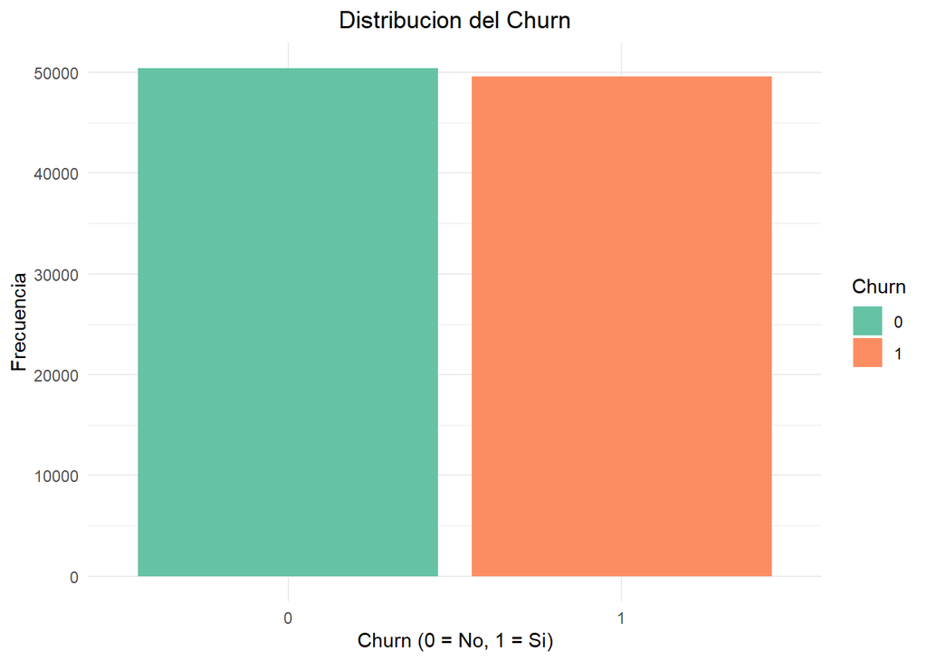

```r
# Visualización: Diagrama de barras para CHURN
ggplot(data, aes(x = as.factor(churn), fill = as.factor(churn))) +
  geom_bar(position = "dodge") +
  labs(title = "Distribucion del Churn",
       x = "Churn (0 = No, 1 = Si)",
       y = "Frecuencia",
       fill = "Churn") +
  theme_minimal() +
  theme(plot.title = element_text(hjust = 0.5)) +
  scale_fill_brewer(palette = "Set2")
```

#### **7.1.4 Grafica de torta del Churn**

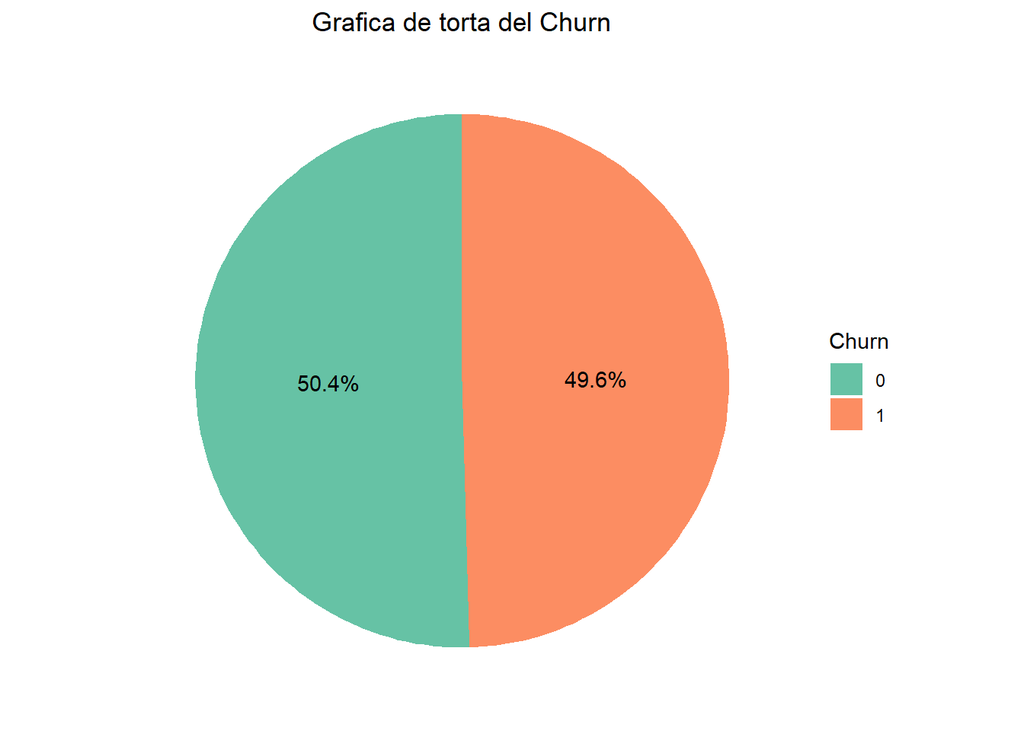

```r
data_summary <- data %>%
  count(churn) %>%
  mutate(percentage = n / sum(n) * 100)

ggplot(data_summary, aes(x = "", y = n, fill = as.factor(churn))) +
  geom_bar(stat = "identity", width = 1) +
  coord_polar("y") +
  geom_text(aes(label = paste0(round(percentage, 1), "%")),
            position = position_stack(vjust = 0.5)) +
  labs(
    title = "Grafica de torta del Churn",
    x = NULL,  # Remove x-axis label
    y = NULL,  # Remove y-axis label
    fill = "Churn"
  ) +
  theme_minimal() +
  theme(
    plot.title = element_text(hjust = 0.5),
    axis.text = element_blank(),  # Remove axis text
    axis.ticks = element_blank(),  # Remove axis ticks
    panel.grid = element_blank()  # Remove grid lines
  ) +
  scale_fill_brewer(palette = "Set2")
```

Dado el contexto de competencia en el sector de telecomunicaciones y la importancia de retener a los clientes, la tasa de abandono del 49.56% de los 100,000 clientes (49,562 usuarios) es un indicador crucial que refleja áreas de mejora en la satisfacción y fidelización del cliente. Este índice de churn sugiere que casi la mitad de los clientes encuentra suficiente motivación para cambiar de proveedor o cancelar el servicio, lo que representa una considerable pérdida de ingresos y una señal de posibles deficiencias en la percepción de valor agregado.

#### **7.1.5 Gráfico de barras de usuarios por nuevo usuarios**

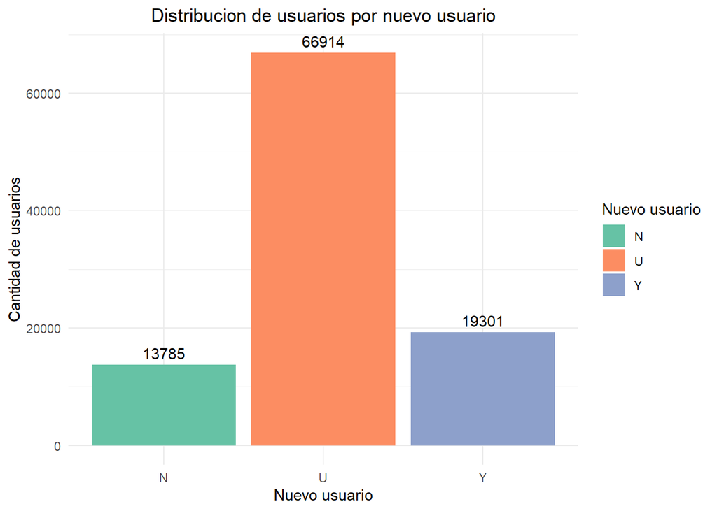

```r
ggplot(data, aes(x = new_cell, fill = new_cell)) +
  geom_bar() +
  geom_text(stat = "count", aes(label = ..count..), vjust = -0.5) +  # Add count labels
  theme_minimal() +
  theme(plot.title = element_text(hjust = 0.5)) +
  labs(
    title = "Distribucion de usuarios por nuevo usuario",
    x = "Nuevo usuario",
    y = "Cantidad de usuarios",
    fill = "Nuevo usuario"
  ) +
  scale_fill_brewer(palette = "Set2")
```

En este diagrama de Barras podemos observar 3 niveles (categorías) que corresponden a N, U y Y. Podemos observar que la frecuencia más alta radica en usuarios demarcados en el grupo U, con más de 50.000 usuarios registrados. Y el grupo con menores usuarios registrados es el N con menos de 20000 registros. El comportamiento de cambio de número entre los usuarios proporciona información importante sobre el manejo de datos, la experiencia del cliente y las razones potenciales de abandono en el contexto de telecomunicaciones.

#### **7.1.6 Distribución de usuarios por nuevo usuarios**

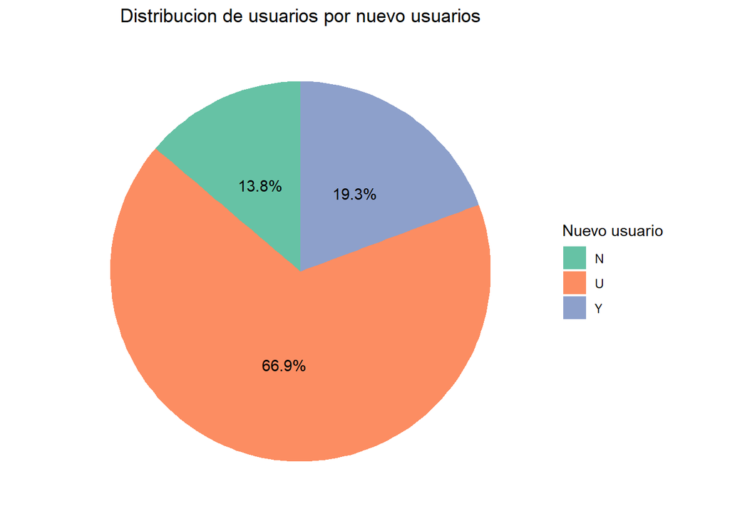

```r
data_summary <- data %>%
  count(new_cell) %>%
  mutate(percentage = n / sum(n) * 100,
         label = paste0(round(percentage, 1), "%"))

ggplot(data_summary, aes(x = "", y = n, fill = new_cell)) +
  geom_bar(stat = "identity", width = 1) +
  coord_polar("y") +
  labs(
    title = "Distribucion de usuarios por nuevo usuarios",
    x = NULL,  # Remove x-axis label
    y = NULL,  # Remove y-axis label
    fill = "Nuevo usuario"
  ) +
  geom_text(aes(label = label), position = position_stack(vjust = 0.5)) +
  theme_minimal() +
  theme(
    plot.title = element_text(hjust = 0.5),
    axis.text = element_blank(),  # Remove axis text
    axis.ticks = element_blank(),  # Remove axis ticks
    panel.grid = element_blank()  # Remove grid lines
  ) +
  scale_fill_brewer(palette = "Set2")
```

Este gráfico de torta representa tres niveles de la variable “nuevo usuario”, que refleja qué tan reciente es su incorporación a la telefonía móvil: **N**, **U**, y **Y**. El grupo **U** concentra la mayoría de los usuarios, con una distribución del **66.9%**, seguido por el grupo **Y**, que representa el **19.3%**, y finalmente el grupo **N**, que constituye el **13.8%**, siendo el más pequeño. Este análisis permite comprender la antigüedad de los usuarios en el servicio y su distribución por niveles.

#### **7.1.7 Distribución del promedio de llamadas de voz fallidas**

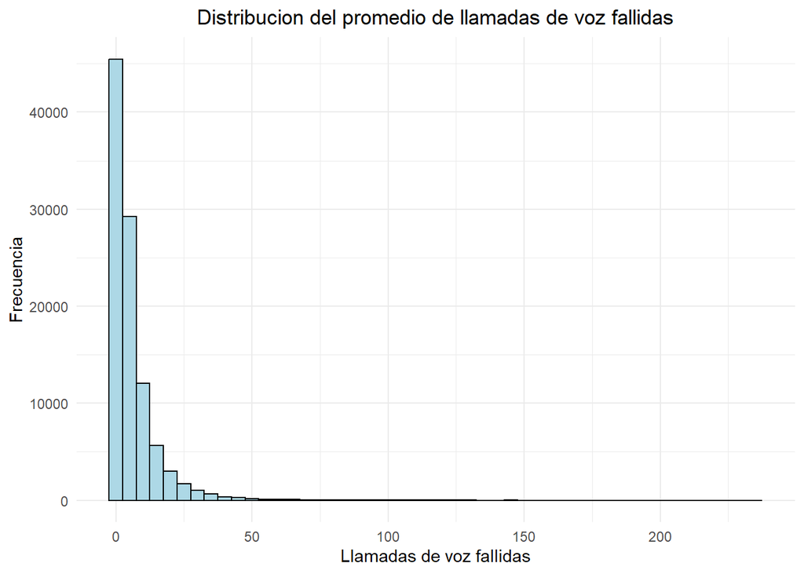

```r
ggplot(data, aes(x = drop_vce_Mean)) +
  geom_histogram(binwidth = 5, fill = "lightblue", color = "black") +
  labs(title = "Distribucion del promedio de llamadas de voz fallidas",
       x = "Llamadas de voz fallidas",
       y = "Frecuencia") +
  theme_minimal() +
  theme(plot.title = element_text(hjust = 0.5)) +
  scale_fill_brewer(palette = "Set2")
```

El sesgo a la derecha en el diagrama de barras, que muestra una concentración de datos en valores bajos de fallas en llamadas, es una señal positiva sobre la calidad del servicio de telecomunicaciones, ya que indica que la mayoría de los usuarios experimenta pocas o ninguna llamada fallida. La concentración de datos en valores bajos sugiere que la red es confiable, y que la infraestructura técnica está funcionando bien para la mayoría de los usuarios. Esto ayuda a mejorar la percepción de calidad y reduce la probabilidad de abandono, ya que la experiencia de llamada es consistente.

#### **7.1.8 Distribución de la cantidad de minutos usados**

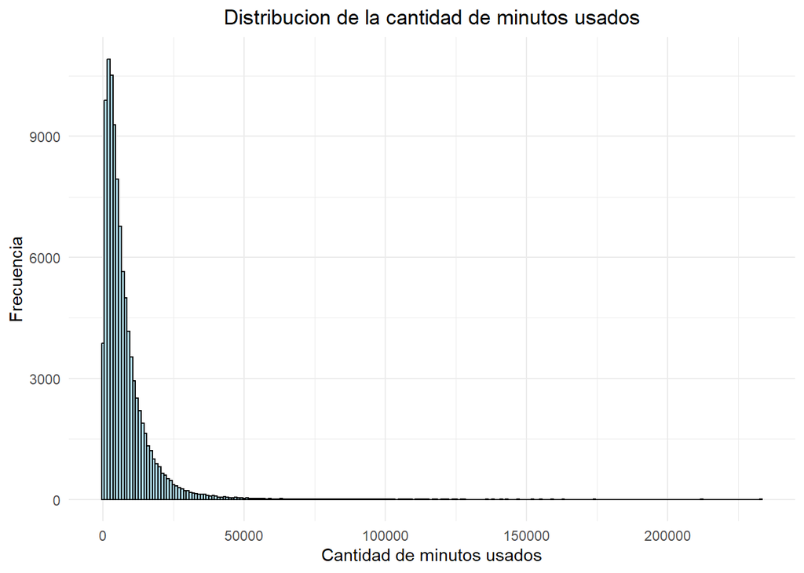

```r
ggplot(data, aes(x = totmou)) +
  geom_histogram(binwidth = 1000, fill = "lightblue", color = "black") +
  labs(title = "Distribucion de la cantidad de minutos usados",
       x = "Cantidad de minutos usados",
       y = "Frecuencia") +
  theme_minimal() +
  theme(plot.title = element_text(hjust = 0.5)) +
  scale_fill_brewer(palette = "Set2")
```

#### **7.1.9 Distribución de la Cantidad de Total de Llamadas**

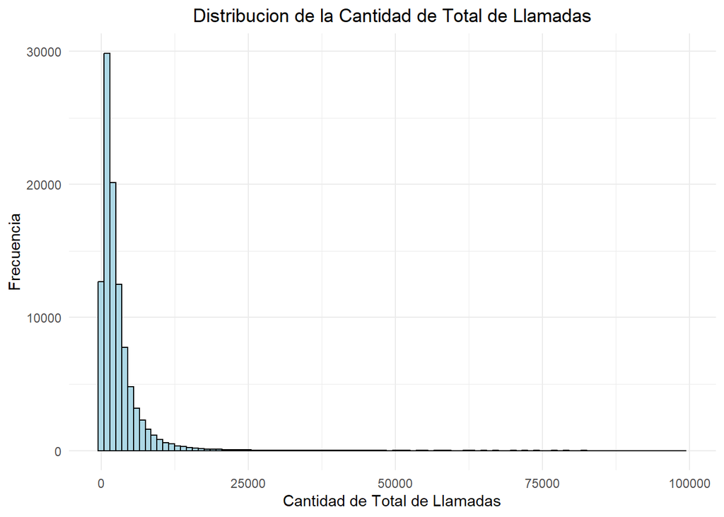

```r
ggplot(data, aes(x = totcalls)) +
  geom_histogram(binwidth = 1000, fill = "lightblue", color = "black") +
  labs(title = "Distribucion de la Cantidad de Total de Llamadas",
       x = "Cantidad de Total de Llamadas",
       y = "Frecuencia") +
  theme_minimal() +
  theme(plot.title = element_text(hjust = 0.5)) +
  scale_fill_brewer(palette = "Set2")
```

#### **7.1.10 Grafica de barras de la etnicidad**

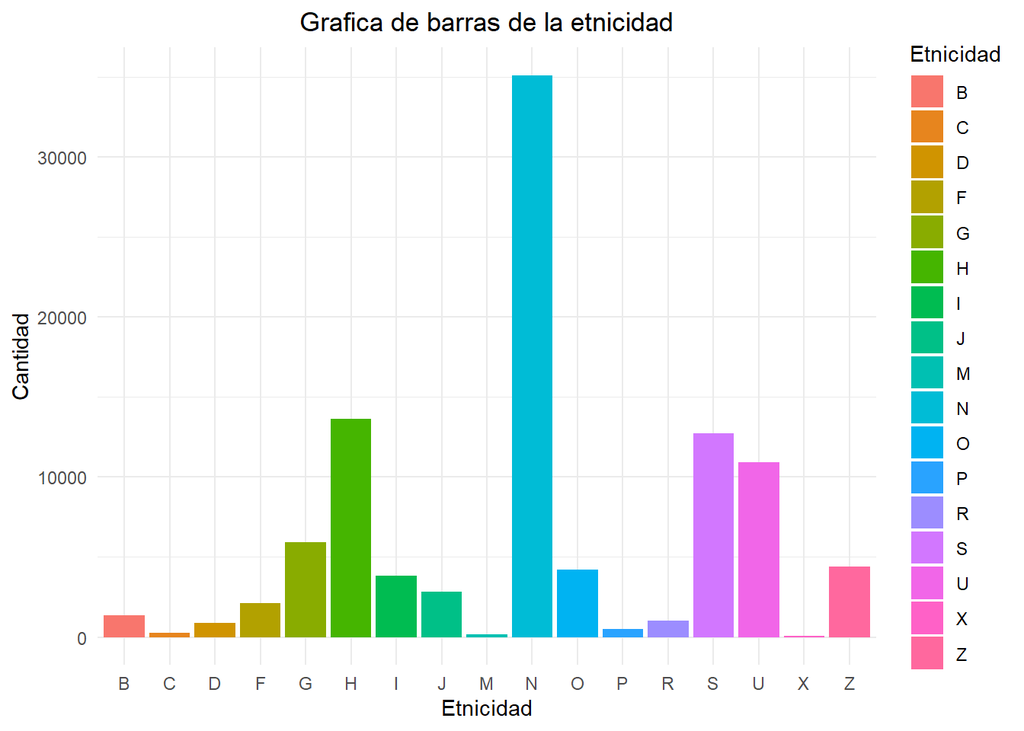

```r
ggplot(data, aes(x=as.factor(ethnic), fill=as.factor(ethnic) )) +
  geom_bar( ) +
  labs(title = "Grafica de barras de la etnicidad", x = "Etnicidad", y = "Cantidad", fill = "Etnicidad") +
  theme_minimal() +
  theme(plot.title = element_text(hjust = 0.5))
```

Se observa que los tres grupos étnicos más frecuentes son el grupo N, seguido por el grupo H y, en tercer lugar, el grupo S. La distribución de estos tres grupos étnicos principales (N, H y S) en el análisis de clientes puede tener varias implicaciones para la compañía, especialmente en la personalización de servicios y en las estrategias de marketing y retención. La identificación de los grupos étnicos más frecuentes permite personalizar servicios y ofertas que puedan resonar mejor con cada grupo. Esto puede incluir campañas de marketing culturalmente relevantes, la incorporación de beneficios específicos que respondan a preferencias o necesidades particulares, o la adaptación de la atención al cliente para reflejar prácticas y valores de cada grupo.

#### **7.1.11 Distribución de Número de Adultos**

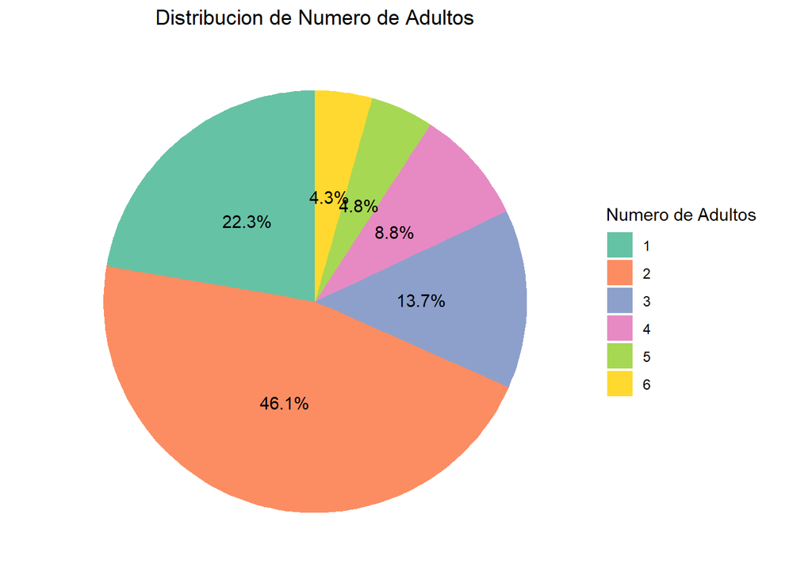

```r
# Calculate the counts and percentages
data_summary <- data %>%
  count(adults) %>%
  mutate(percentage = n / sum(n) * 100)

# Create the pie chart
ggplot(data_summary, aes(x = "", y = n, fill = as.factor(adults))) +
  geom_bar(stat = "identity", width = 1) +
  coord_polar("y") +
  geom_text(aes(label = paste0(round(percentage, 1), "%")),
            position = position_stack(vjust = 0.5)) +
  labs(title = "Distribucion de Numero de Adultos",
       x = NULL,
       y = NULL,
       fill = "Numero de Adultos") +
  theme_minimal() +
  theme(
    plot.title = element_text(hjust = 0.5),
    axis.text = element_blank(),  # Remove axis text
    axis.ticks = element_blank(),  # Remove axis ticks
    panel.grid = element_blank()  # Remove grid lines
  ) +
  scale_fill_brewer(palette = "Set2")
```

La variable “número de adultos” representa la cantidad de personas adultas que viven en el hogar del cliente. Este gráfico muestra la distribución porcentual de esta variable, donde los hogares con **dos adultos** son mayoría con un **46.1%**, seguidos por los hogares con **un adulto** con un **22.3%**, luego **tres adultos** con un **13.7%**, **cuatro adultos** con un **8.8%**, **cinco adultos** con un **4.8%** y, finalmente, **seis adultos** con un **4.3%**. Este análisis es útil para comprender las características de los clientes y evaluar si el número de adultos en el hogar influye en el comportamiento del cliente, como mayores gastos o una mayor necesidad de servicios de telecomunicaciones, lo que podría impactar en la rotación (churn).

#### **7.1.12 Distribución del total de meses en el servicio**

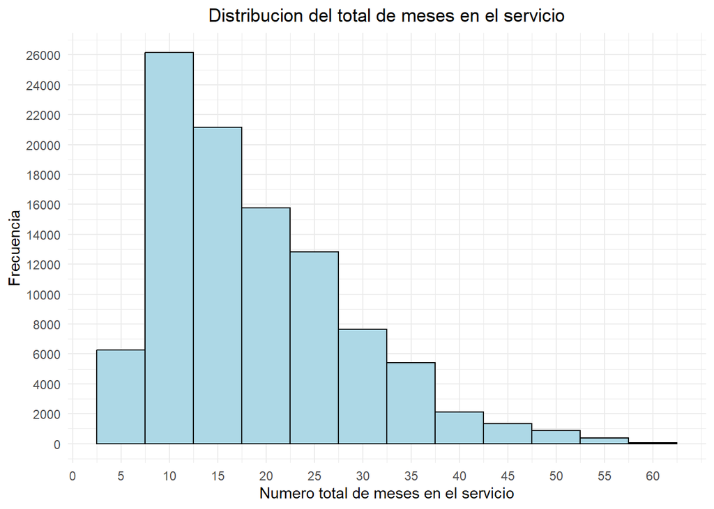

```r
ggplot(data, aes(x = months)) +
  geom_histogram(binwidth = 5, fill = "lightblue", color = "black") +
  labs(
    title = "Distribucion del total de meses en el servicio",
    x = "Numero total de meses en el servicio",
    y = "Frecuencia"
  ) +
  theme_minimal() +
  theme(plot.title = element_text(hjust = 0.5)) +
  scale_x_continuous(breaks = seq(0, max(data$months, na.rm = TRUE), by = 5)) +  # Set x-axis breaks
  scale_y_continuous(breaks = seq(0, max(table(cut(data$months, seq(0, max(data$months, na.rm = TRUE), by = 5)))), by = 2000))
```

Este diagrama muestra un sesgo positivo, con la mayoría de la distribución concentrada entre los **5 y 25 meses**. Esto sugiere que hay una menor cantidad de clientes después de los **25 meses**, lo que indica una tendencia a la disminución de clientes conforme aumenta el tiempo.

#### **7.1.13 Distribución del número de días que el cliente ha tenido su equipo actual.**

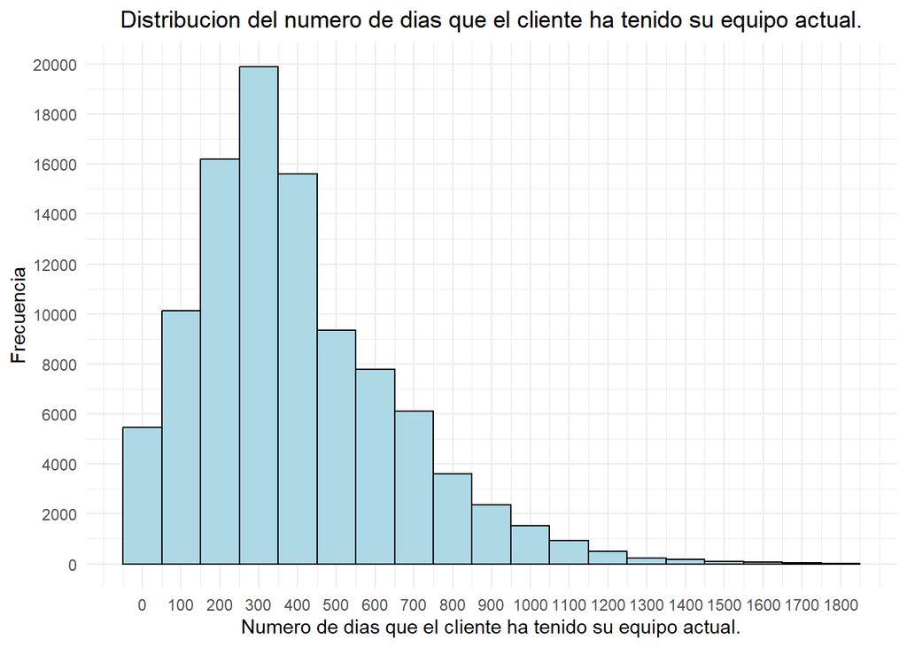

```r
ggplot(data, aes(x = eqpdays)) +
  geom_histogram(binwidth = 100, fill = "lightblue", color = "black") +
  labs(
    title = "Distribucion del numero de dias que el cliente ha tenido su equipo actual.",
    x = "Numero de dias que el cliente ha tenido su equipo actual.",
    y = "Frecuencia"
  ) +
  theme_minimal() +
  theme(plot.title = element_text(hjust = 0.5)) +
  scale_x_continuous(breaks = seq(0, max(data$eqpdays, na.rm = TRUE), by = 100)) +  # Set x-axis breaks
  scale_y_continuous(breaks = seq(0, max(table(cut(data$eqpdays, seq(0, max(data$eqpdays, na.rm = TRUE), by = 100)))), by = 2000))  # Set y-axis breaks
```

Esta distribución presenta un sesgo positivo, con la mayoría de los usuarios concentrados entre **100 y 500 días** desde que adquirieron su equipo actual. Esto indica que, después de los **300 días**, hay una menor cantidad de usuarios con equipos más antiguos, lo cual podría influir en la rotación de clientes (churn), ya que los equipos más viejos pueden estar relacionados con una mayor propensión a quedarse insatisfechos con el servicio.

#### **7.1.14 Distribución del precio del telefono.**

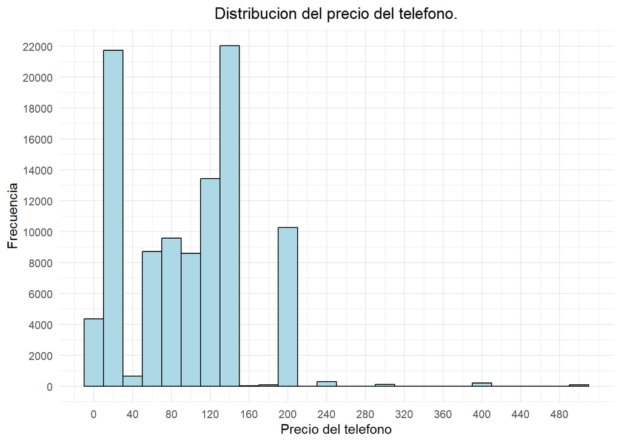

```r
ggplot(data, aes(x = hnd_price)) +
  geom_histogram(binwidth = 20, fill = "lightblue", color = "black") +
  labs(
    title = "Distribucion del precio del telefono.",
    x = "Precio del telefono",
    y = "Frecuencia"
  ) +
  theme_minimal() +
  theme(plot.title = element_text(hjust = 0.5)) +
  scale_x_continuous(breaks = seq(0, max(data$hnd_price, na.rm = TRUE), by = 40)) +  # Set x-axis breaks
  scale_y_continuous(breaks = seq(0, max(table(cut(data$hnd_price, seq(0, max(data$hnd_price, na.rm = TRUE), by = 20)))), by = 2000))  # Set y-axis breaks
```

Se observa que los precios de los teléfonos varían entre **0** y **160**, y que hay menos usuarios con teléfonos cuyo precio excede los **160**.

#### **7.1.15 Distribución de minutos de uso mensual promedio.**

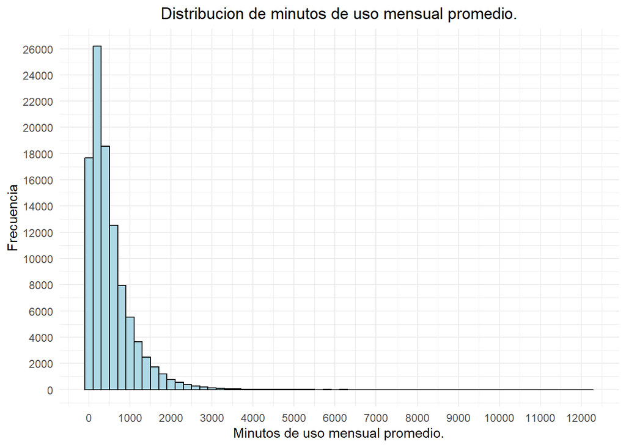

```r
ggplot(data, aes(x = mou_Mean)) +
  geom_histogram(binwidth = 200, fill = "lightblue", color = "black") +
  labs(
    title = "Distribucion de minutos de uso mensual promedio.",
    x = "Minutos de uso mensual promedio.",
    y = "Frecuencia"
  ) +
  theme_minimal() +
  theme(plot.title = element_text(hjust = 0.5)) +
  scale_x_continuous(breaks = seq(0, max(data$mou_Mean, na.rm = TRUE), by = 1000)) +  # Set x-axis breaks
  scale_y_continuous(breaks = seq(0, max(table(cut(data$mou_Mean, seq(0, max(data$mou_Mean, na.rm = TRUE), by = 200)))), by = 2000))  # Set y-axis breaks
```

Esta distribución muestra un sesgo positivo, con la mayoría de los usuarios concentrados en un rango de **0 a 1000 minutos** promedio por mes. Esto sugiere que la mayoría de los usuarios gastan una cantidad moderada de minutos al mes, lo que refleja su comportamiento típico de uso del servicio.

#### **7.1.16 Distribución del cargo recurrente mensual total promedio.**

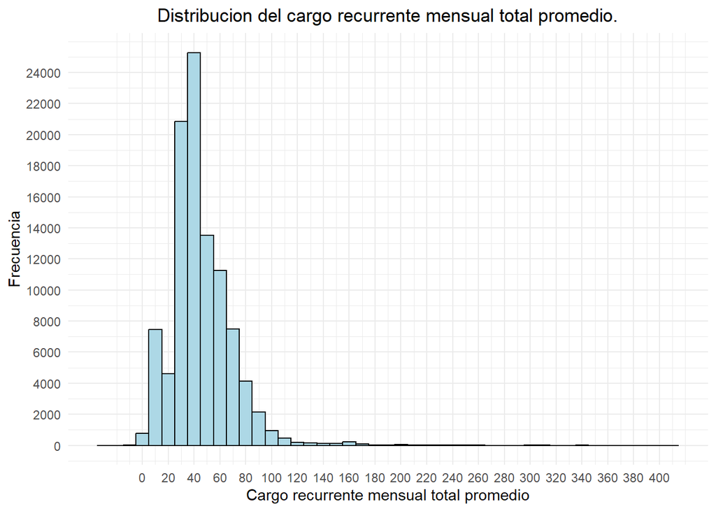

```r
ggplot(data, aes(x = totmrc_Mean)) +
  geom_histogram(binwidth = 10, fill = "lightblue", color = "black") +
  labs(
    title = "Distribucion del cargo recurrente mensual total promedio.",
    x = "Cargo recurrente mensual total promedio",
    y = "Frecuencia"
  ) +
  theme_minimal() +
  theme(plot.title = element_text(hjust = 0.5)) +
  scale_x_continuous(breaks = seq(0, max(data$totmrc_Mean, na.rm = TRUE), by = 20)) +  # Set x-axis breaks
  scale_y_continuous(breaks = seq(0, max(table(cut(data$totmrc_Mean, seq(0, max(data$totmrc_Mean, na.rm = TRUE), by = 10)))), by = 2000))  # Set y-axis breaks
```

La distribución presenta un sesgo positivo, con el cargo recurrente mensual promedio concentrado entre **20** y **80**. Esto indica que la mayoría de los usuarios tienen un cargo mensual dentro de este rango.

#### **7.1.17 Distribución del numero de telefonos.**

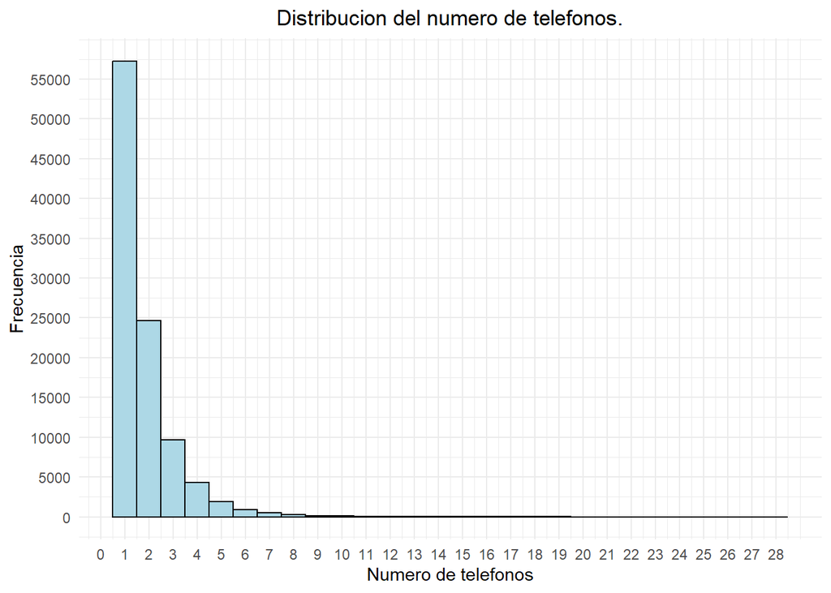

```r
ggplot(data, aes(x = phones)) +
  geom_histogram(binwidth = 1, fill = "lightblue", color = "black") +
  labs(
    title = "Distribucion del numero de telefonos.",
    x = "Numero de telefonos",
    y = "Frecuencia"
  ) +
  theme_minimal() +
  theme(plot.title = element_text(hjust = 0.5)) +
  scale_x_continuous(breaks = seq(0, max(data$phones, na.rm = TRUE), by = 1)) +  # Set x-axis breaks
  scale_y_continuous(breaks = seq(0, max(table(cut(data$phones, seq(0, max(data$phones, na.rm = TRUE), by = 1)))), by = 5000))  # Set y-axis breaks
```

La distribución muestra un sesgo positivo, con una concentración entre **1** y **2 teléfonos**, siendo el **1 teléfono** el caso más común. Es menos frecuente que los usuarios tengan más de **2 teléfonos**.

## **8. Análisis Bivariado**

### **8.1 Frecuencia de Adultos por Churn**

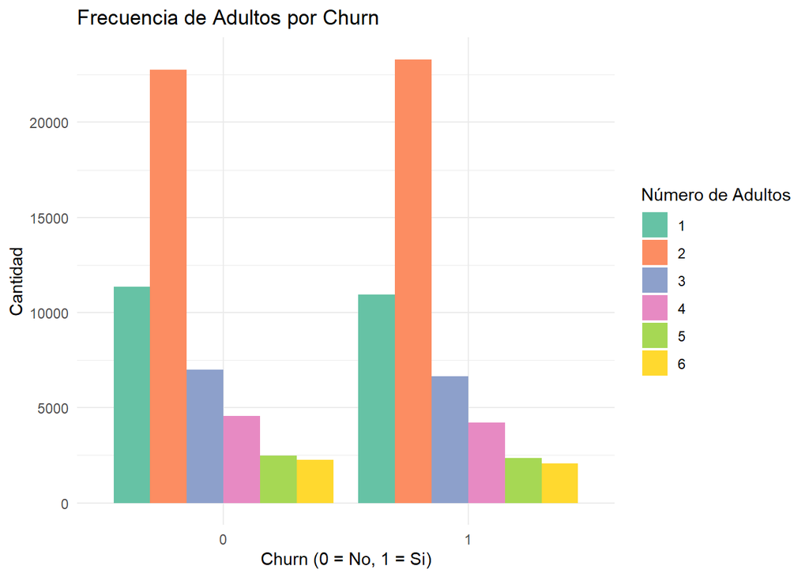

```r
ggplot(data, aes(x = as.factor(churn), fill = as.factor(adults))) +
  geom_bar(position = "dodge") +
  theme_minimal() +
  labs(title = "Frecuencia de Adultos por Churn", x = "Churn (0 = No, 1 = Si)", y = "Cantidad", fill = "Número de Adultos") +
  scale_fill_brewer(palette = "Set2")
```

La ausencia de una influencia visible del número de adultos en el churn indica que esta variable podría no ser un factor determinante en la decisión de los clientes de permanecer o abandonar el servicio. Esto sugiere que el número de adultos en el hogar puede tener una relación muy débil, o incluso inexistente, con la fidelidad o satisfacción de los clientes en este contexto de telecomunicaciones.

### **8.2 Frecuencia de Ingreso por Churn**

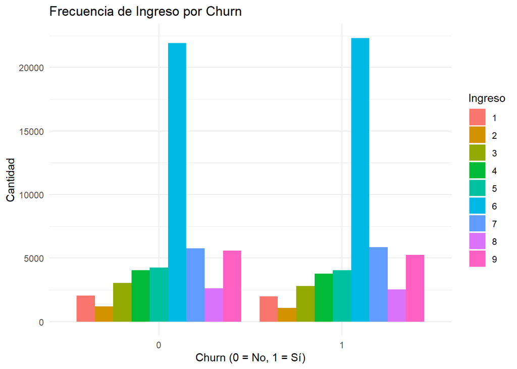

```r
ggplot(data, aes(x = as.factor(churn), fill = as.factor(income))) +
  geom_bar(position = "dodge") +
  theme_minimal() +
  labs(title = "Frecuencia de Ingreso por Churn", x = "Churn (0 = No, 1 = Sí)", y = "Cantidad", fill = "Ingreso")
```

La falta de influencia del ingreso en el churn indica que es posible priorizar otras variables en las estrategias de retención y en la construcción del modelo predictivo. Esto optimiza el análisis, focalizando en factores que realmente afectan la lealtad y satisfacción de los clientes.

### **8.3 Frecuencia de Área por Churn**

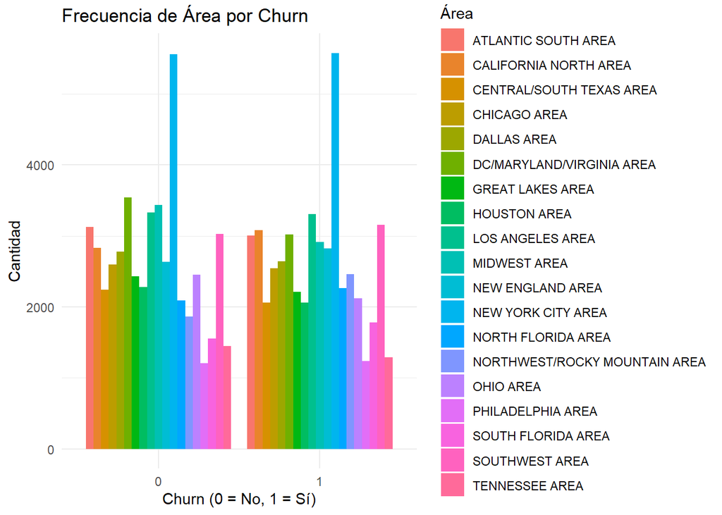

```r
ggplot(data, aes(x = as.factor(churn), fill = area)) +
  geom_bar(position = "dodge") +
  theme_minimal() +
  labs(title = "Frecuencia de Área por Churn", x = "Churn (0 = No, 1 = Sí)", y = "Cantidad", fill = "Área")
```

No se observa ninguna influencia de las áreas geográficas en el churn.

### **8.4 Frecuencia de Etnicidad por Churn**

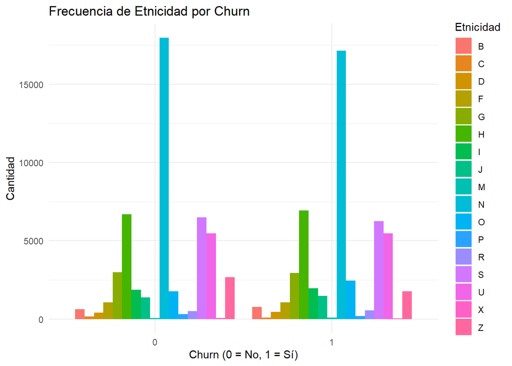

```r
ggplot(data, aes(x = as.factor(churn), fill = ethnic)) +
  geom_bar(position = "dodge") +
  theme_minimal() +
  labs(title = "Frecuencia de Etnicidad por Churn", x = "Churn (0 = No, 1 = Sí)", y = "Cantidad", fill = "Etnicidad")
```

No observamos una relación clara entre los grupos étnicos y en el churn.

### **8.5 Frecuencia de Estado Civil por Churn**

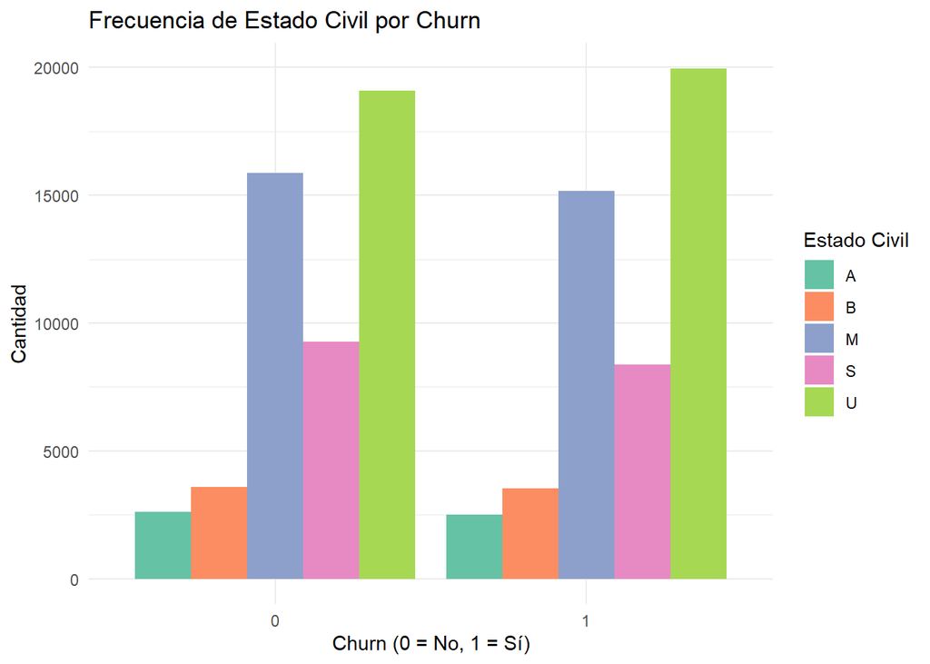

```r
ggplot(data, aes(x = as.factor(churn), fill = marital)) +
  geom_bar(position = "dodge") +
  theme_minimal() +
  labs(title = "Frecuencia de Estado Civil por Churn", x = "Churn (0 = No, 1 = Sí)", y = "Cantidad", fill = "Estado Civil") +
  scale_fill_brewer(palette = "Set2")
```

Al comparar el estado civil de los clientes, no se observa una diferencia significativa en el churn.

### **8.6 Caja de bigotes de Promedio de llamadas no contestadas por Churn**

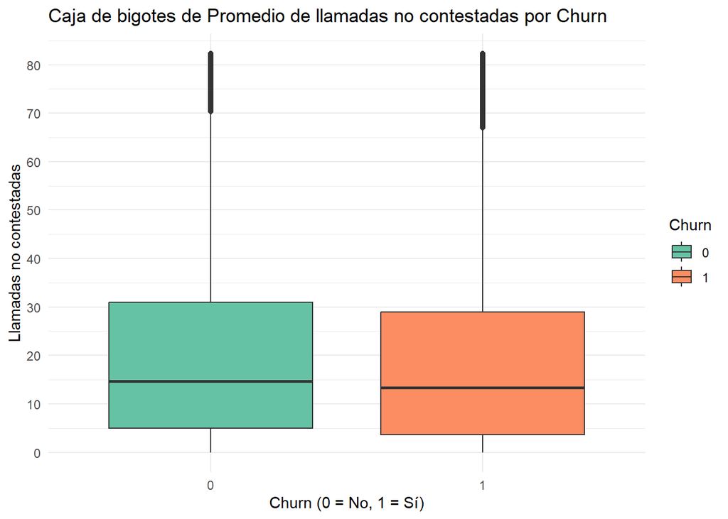

```r
# Calculate the IQR and define the outlier bounds
Q1 <- quantile(data$unan_vce_Mean, 0.25, na.rm = TRUE)
Q3 <- quantile(data$unan_vce_Mean, 0.75, na.rm = TRUE)
IQR_value <- Q3 - Q1

# Define the lower and upper bounds for outliers
lower_bound <- Q1 - 1.5 * IQR_value
upper_bound <- Q3 + 1.5 * IQR_value

# Filter data to exclude outliers
filtered_data <- data %>%
  filter(unan_vce_Mean >= lower_bound & unan_vce_Mean <= upper_bound)

# Plot without outliers
ggplot(filtered_data, aes(x = as.factor(churn), y = unan_vce_Mean, fill = as.factor(churn))) +
  geom_boxplot() +
  theme_minimal() +
  scale_y_continuous(breaks = seq(floor(min(filtered_data$unan_vce_Mean)),
                                  ceiling(max(filtered_data$unan_vce_Mean)),
                                  by = 10)) +
  labs(title = "Caja de bigotes de Promedio de llamadas no contestadas por Churn",
       x = "Churn (0 = No, 1 = Sí)",
       y = "Llamadas no contestadas",
       fill = "Churn") +
  scale_fill_brewer(palette = "Set2")
```

La observación de que ambas cajas de bigotes (box plots) para los estados de churn (0 y 1) presentan un sesgo positivo y una mediana similar, con la mayoría de los datos en el rango de 5 a 30, sugiere que el promedio de llamadas no contestadas podría no ser un factor relevante para explicar el abandono del servicio. Si no se aprecian diferencias significativas en la distribución entre los clientes que permanecen (churn = 0) y los que abandonan (churn = 1), es probable que el promedio de llamadas no contestadas tenga una baja influencia en la decisión de abandono.

### **8.7 Caja de bigotes de Promedio de llamadas esperadas por Churn**

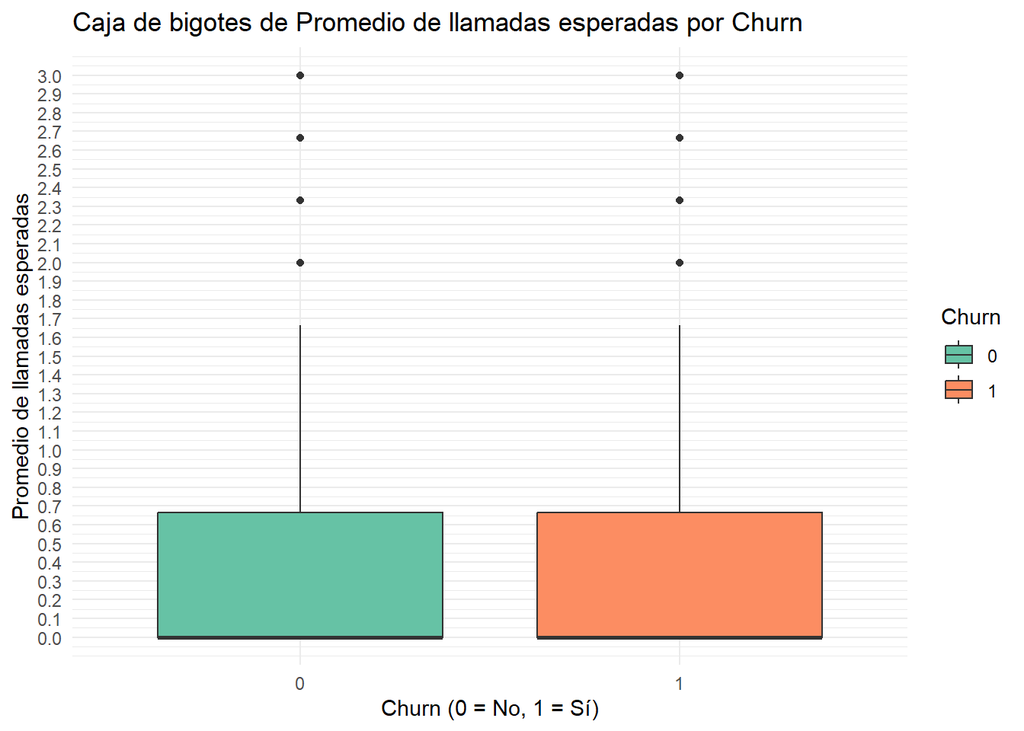

```r
# Calculate the IQR and define the outlier bounds
Q1 <- quantile(data$callwait_Mean, 0.25, na.rm = TRUE)
Q3 <- quantile(data$callwait_Mean, 0.75, na.rm = TRUE)
IQR_value <- Q3 - Q1

# Define the lower and upper bounds for outliers
lower_bound <- Q1 - 1.5 * IQR_value
upper_bound <- Q3 + 1.5 * IQR_value

# Filter data to exclude outliers
filtered_data <- data %>%
  filter(unan_vce_Mean >= lower_bound & callwait_Mean <= upper_bound)

# Plot without outliers
ggplot(filtered_data, aes(x = as.factor(churn), y = callwait_Mean, fill = as.factor(churn))) +
  geom_boxplot() +
  theme_minimal() +
  scale_y_continuous(breaks = seq(floor(min(filtered_data$callwait_Mean)),
                                  ceiling(max(filtered_data$callwait_Mean)),
                                  by = 0.1)) +
  labs(title = "Caja de bigotes de Promedio de llamadas esperadas por Churn",
       x = "Churn (0 = No, 1 = Sí)",
       y = "Promedio de llamadas esperadas",
       fill = "Churn") +
  scale_fill_brewer(palette = "Set2")
```

La observación de que ambas cajas de bigotes para los estados de churn (0 y 1) muestran un sesgo positivo, con medianas similares y la mayoría de los datos en el rango de 0.0 a 0.7 en el promedio de llamadas esperadas, sugiere que esta variable no es un factor diferenciador entre clientes que abandonan y aquellos que permanecen. La falta de diferencias significativas entre las distribuciones para churn indica que el promedio de llamadas esperadas probablemente no influye en la decisión de abandono.

### **8.8 Número total de meses en el servicio por Churn**

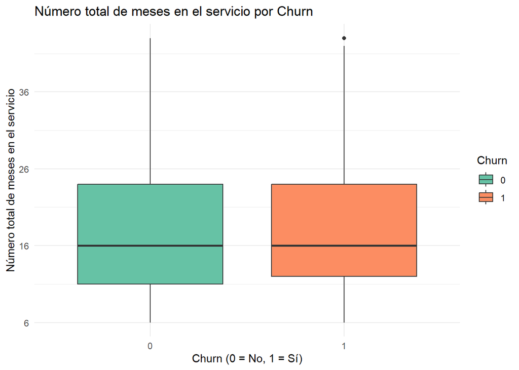

```r
# Calculate the IQR and define the outlier bounds
Q1 <- quantile(data$months, 0.25, na.rm = TRUE)
Q3 <- quantile(data$months, 0.75, na.rm = TRUE)
IQR_value <- Q3 - Q1

# Define the lower and upper bounds for outliers
lower_bound <- Q1 - 1.5 * IQR_value
upper_bound <- Q3 + 1.5 * IQR_value

# Filter data to exclude outliers
filtered_data <- data %>%
  filter(months >= lower_bound & months <= upper_bound)

# Plot without outliers
ggplot(filtered_data, aes(x = as.factor(churn), y = months, fill = as.factor(churn))) +
  geom_boxplot() +
  theme_minimal() +
  scale_y_continuous(breaks = seq(floor(min(filtered_data$months)),
                                  ceiling(max(filtered_data$months)),
                                  by = 10)) +
  labs(title = "Número total de meses en el servicio por Churn",
       x = "Churn (0 = No, 1 = Sí)",
       y = "Número total de meses en el servicio",
       fill = "Churn") +
  scale_fill_brewer(palette = "Set2")
```

Visualmente, no se observa una diferencia significativa en la influencia del número total de meses en el servicio sobre el churn. Esto se debe a que tanto la media de los datos como el tamaño de las cajas entre las categorías 0 y 1 son muy similares.

### **8.9 Edad del equipo por Churn**

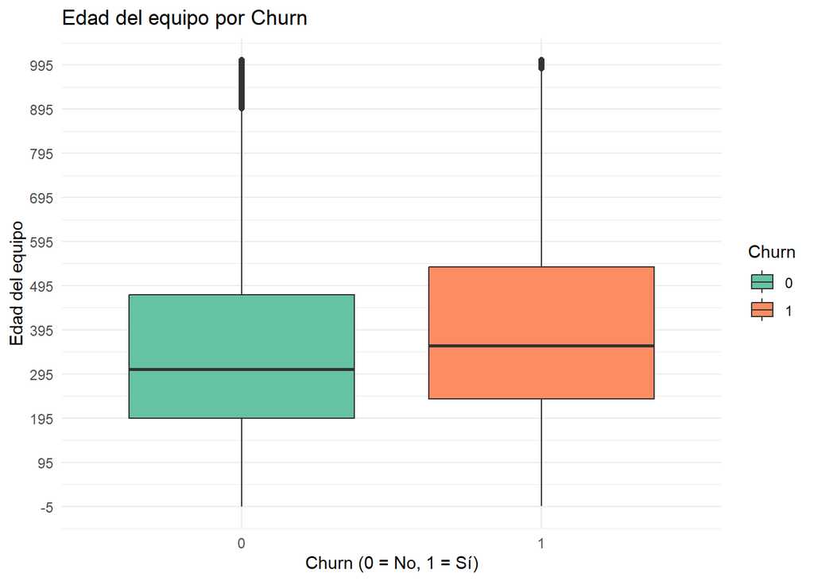

```r
# Calculate the IQR and define the outlier bounds
Q1 <- quantile(data$eqpdays, 0.25, na.rm = TRUE)
Q3 <- quantile(data$eqpdays, 0.75, na.rm = TRUE)
IQR_value <- Q3 - Q1

# Define the lower and upper bounds for outliers
lower_bound <- Q1 - 1.5 * IQR_value
upper_bound <- Q3 + 1.5 * IQR_value

# Filter data to exclude outliers
filtered_data <- data %>%
  filter(eqpdays >= lower_bound & eqpdays <= upper_bound)

# Plot without outliers
ggplot(filtered_data, aes(x = as.factor(churn), y = eqpdays, fill = as.factor(churn))) +
  geom_boxplot() +
  theme_minimal() +
  scale_y_continuous(breaks = seq(floor(min(filtered_data$eqpdays)),
                                  ceiling(max(filtered_data$eqpdays)),
                                  by = 100)) +
  labs(title = "Edad del equipo por Churn",
       x = "Churn (0 = No, 1 = Sí)",
       y = "Edad del equipo",
       fill = "Churn") +
  scale_fill_brewer(palette = "Set2")
```

El boxplot sugiere una ligera tendencia que indica que los clientes que realizaron churn tienden a tener una mayor antigüedad con el dispositivo que utilizan.

### **8.10 Precio del telefono por Churn**

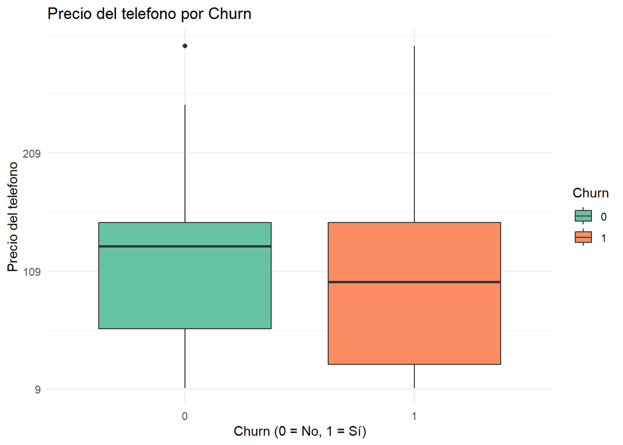

```r
# Calculate the IQR and define the outlier bounds
Q1 <- quantile(data$hnd_price, 0.25, na.rm = TRUE)
Q3 <- quantile(data$hnd_price, 0.75, na.rm = TRUE)
IQR_value <- Q3 - Q1

# Define the lower and upper bounds for outliers
lower_bound <- Q1 - 1.5 * IQR_value
upper_bound <- Q3 + 1.5 * IQR_value

# Filter data to exclude outliers
filtered_data <- data %>%
  filter(hnd_price >= lower_bound & hnd_price <= upper_bound)

# Plot without outliers
ggplot(filtered_data, aes(x = as.factor(churn), y = hnd_price, fill = as.factor(churn))) +
  geom_boxplot() +
  theme_minimal() +
  scale_y_continuous(breaks = seq(floor(min(filtered_data$hnd_price)),
                                  ceiling(max(filtered_data$hnd_price)),
                                  by = 100)) +
  labs(title = "Precio del telefono por Churn",
       x = "Churn (0 = No, 1 = Sí)",
       y = "Precio del telefono",
       fill = "Churn") +
  scale_fill_brewer(palette = "Set2")
```

La gráfica sugiere que el precio del teléfono podría influir en la decisión de churn de un cliente. Sin embargo, sería necesario analizar esta relación en conjunto con otras variables para confirmar esta hipótesis.

### **8.11 Minutos de uso mensual promedio por Churn**

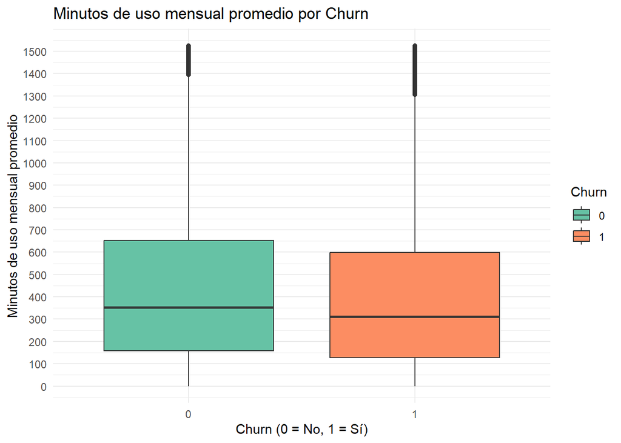

```r
# Calculate the IQR and define the outlier bounds
Q1 <- quantile(data$mou_Mean, 0.25, na.rm = TRUE)
Q3 <- quantile(data$mou_Mean, 0.75, na.rm = TRUE)
IQR_value <- Q3 - Q1

# Define the lower and upper bounds for outliers
lower_bound <- Q1 - 1.5 * IQR_value
upper_bound <- Q3 + 1.5 * IQR_value

# Filter data to exclude outliers
filtered_data <- data %>%
  filter(mou_Mean >= lower_bound & mou_Mean <= upper_bound)

# Plot without outliers
ggplot(filtered_data, aes(x = as.factor(churn), y = mou_Mean, fill = as.factor(churn))) +
  geom_boxplot() +
  theme_minimal() +
  scale_y_continuous(breaks = seq(floor(min(filtered_data$mou_Mean)),
                                  ceiling(max(filtered_data$mou_Mean)),
                                  by = 100)) +
  labs(title = "Minutos de uso mensual promedio por Churn",
       x = "Churn (0 = No, 1 = Sí)",
       y = "Minutos de uso mensual promedio",
       fill = "Churn") +
  scale_fill_brewer(palette = "Set2")
```

La gráfica no permite determinar si el promedio de minutos de uso mensual tiene alguna influencia en el churn de los clientes.

### **8.12 Cargo recurrente mensual total promedio por Churn.**

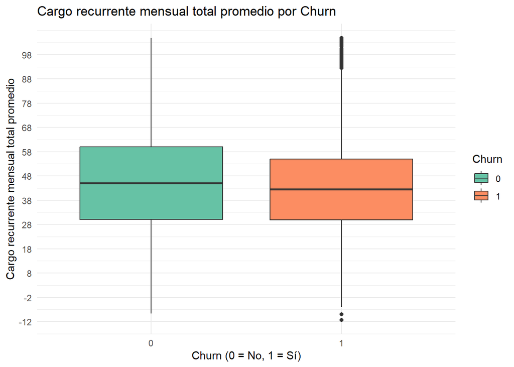

```r
# Calculate the IQR and define the outlier bounds
Q1 <- quantile(data$totmrc_Mean, 0.25, na.rm = TRUE)
Q3 <- quantile(data$totmrc_Mean, 0.75, na.rm = TRUE)
IQR_value <- Q3 - Q1

# Define the lower and upper bounds for outliers
lower_bound <- Q1 - 1.5 * IQR_value
upper_bound <- Q3 + 1.5 * IQR_value

# Filter data to exclude outliers
filtered_data <- data %>%
  filter(totmrc_Mean >= lower_bound & totmrc_Mean <= upper_bound)

# Plot without outliers
ggplot(filtered_data, aes(x = as.factor(churn), y = totmrc_Mean, fill = as.factor(churn))) +
  geom_boxplot() +
  theme_minimal() +
  scale_y_continuous(breaks = seq(floor(min(filtered_data$totmrc_Mean)),
                                  ceiling(max(filtered_data$totmrc_Mean)),
                                  by = 10)) +
  labs(title = "Cargo recurrente mensual total promedio por Churn",
       x = "Churn (0 = No, 1 = Sí)",
       y = "Cargo recurrente mensual total promedio",
       fill = "Churn") +
  scale_fill_brewer(palette = "Set2")
```

Se observa una ligera relación entre los clientes que no realizaron churn y el promedio del cargo recurrente mensual total.

### **8.13 Número de telefonos por Churn**

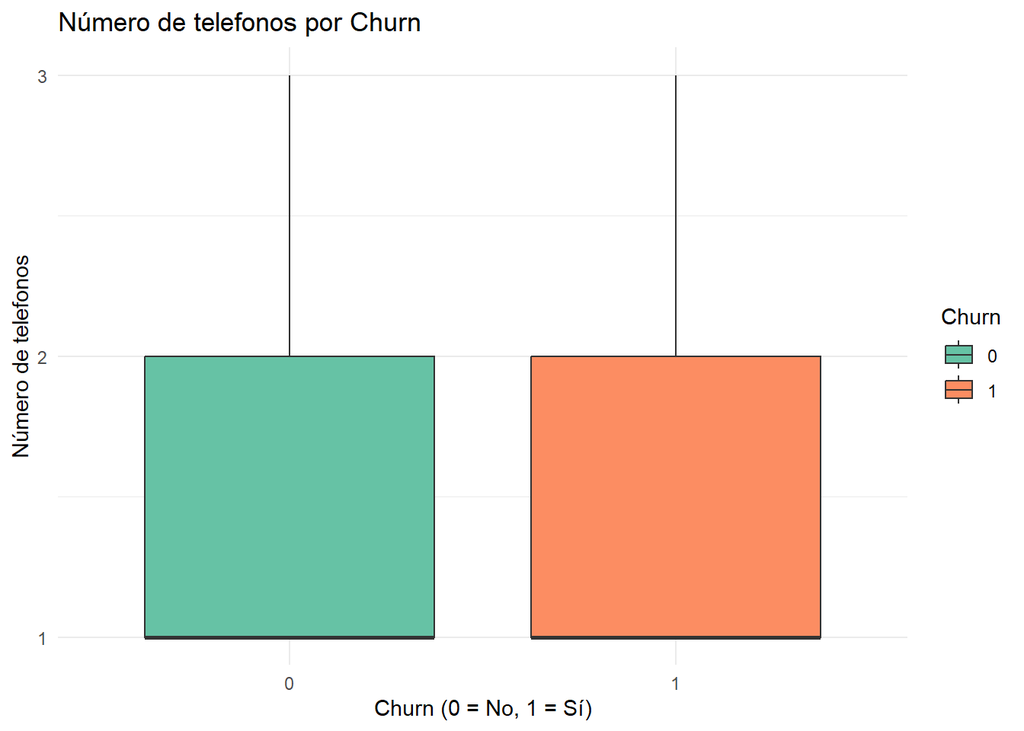

```r
# Calculate the IQR and define the outlier bounds
Q1 <- quantile(data$phones, 0.25, na.rm = TRUE)
Q3 <- quantile(data$phones, 0.75, na.rm = TRUE)
IQR_value <- Q3 - Q1

# Define the lower and upper bounds for outliers
lower_bound <- Q1 - 1.5 * IQR_value
upper_bound <- Q3 + 1.5 * IQR_value

# Filter data to exclude outliers
filtered_data <- data %>%
  filter(phones >= lower_bound & phones <= upper_bound)

# Plot without outliers
ggplot(filtered_data, aes(x = as.factor(churn), y = phones, fill = as.factor(churn))) +
  geom_boxplot() +
  theme_minimal() +
  scale_y_continuous(breaks = seq(floor(min(filtered_data$phones)),
                                  ceiling(max(filtered_data$phones)),
                                  by = 1)) +
  labs(title = "Número de telefonos por Churn",
       x = "Churn (0 = No, 1 = Sí)",
       y = "Número de telefonos",
       fill = "Churn") +
  scale_fill_brewer(palette = "Set2")
```

Visualmente, no es posible distinguir si existe una relación entre el número de teléfonos y la decisión del cliente de hacer churn.